# Diapositivas de apoyo

Estadística para las Ciencias Sociales

Manuel Mejía

CETYS Universidad

27/January/2023

# Tamaño de muestra

## El error no disminuye linealmente

El “sentido común” nos diría que si aumentamos el tamaño de muestra de nuestro estudio, tendremos menor margen de error (mayor certidumbre) en el resultado. Y que por lo tanto, siempre conviene aumentar el tamaño de muestra.

Se pensaría que cada persona que agreguemos a nuestra muestra, ayudará a disminuir el error como se ve en la gráfica: linealmente se va reduciendo el error.

Pero esto es incorrecto.

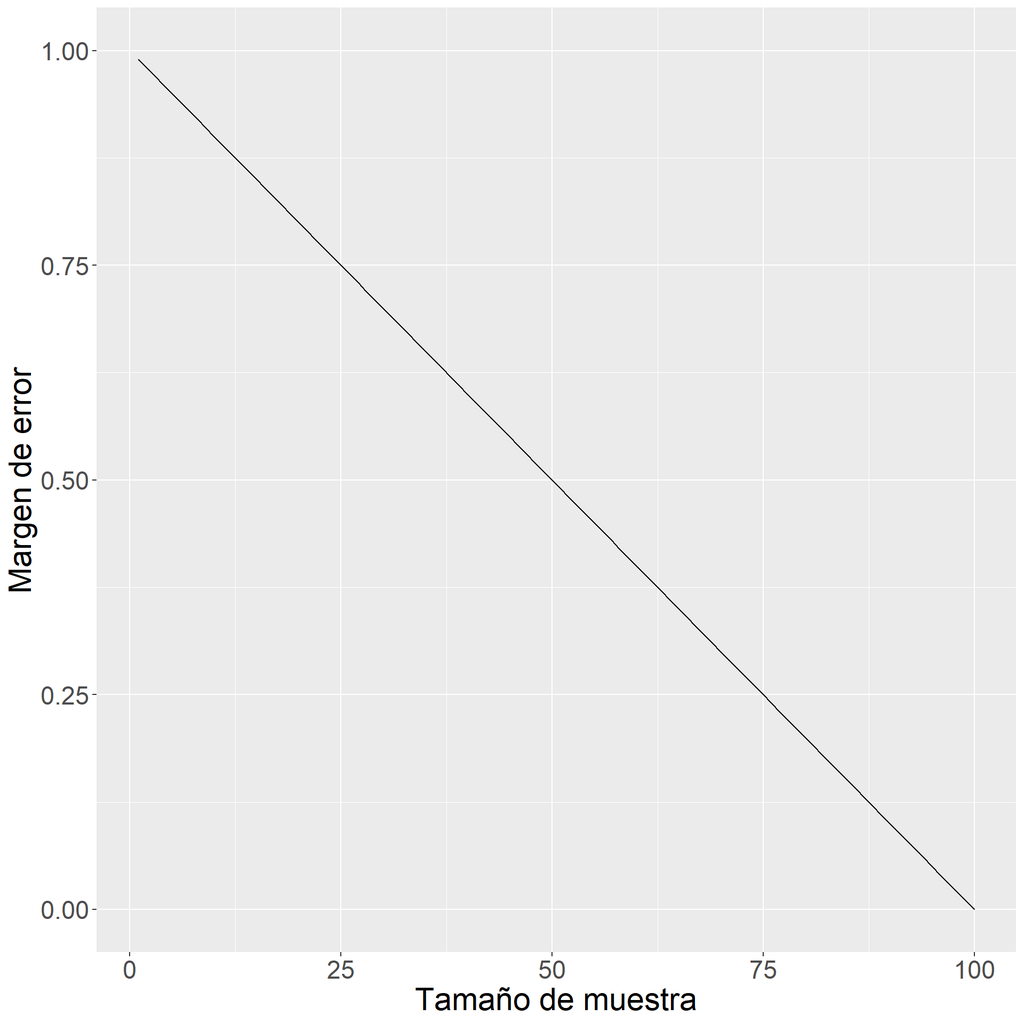

[figure not shown]

## El error disminuye decrecientemente

Lo que realmente sucede es que el error sí va disminuyendo, pero lo que se disminuye con la segunda persona de nuestra muestra es mayor que lo que disminuye con la 100va persona de la muestra. Cada persona que agreguemos, va agregando **menos** a nuestra certidumbre.

Esto se explica porque la fórmula es:
$$Error = \frac{\sigma}{\sqrt{n}}$$

La gráfica muestra que el error disminuye mucho con las primeras 20 personas. Pero después de esas 20, las demás que agregamos disminuyen muy poco ese margen de error.

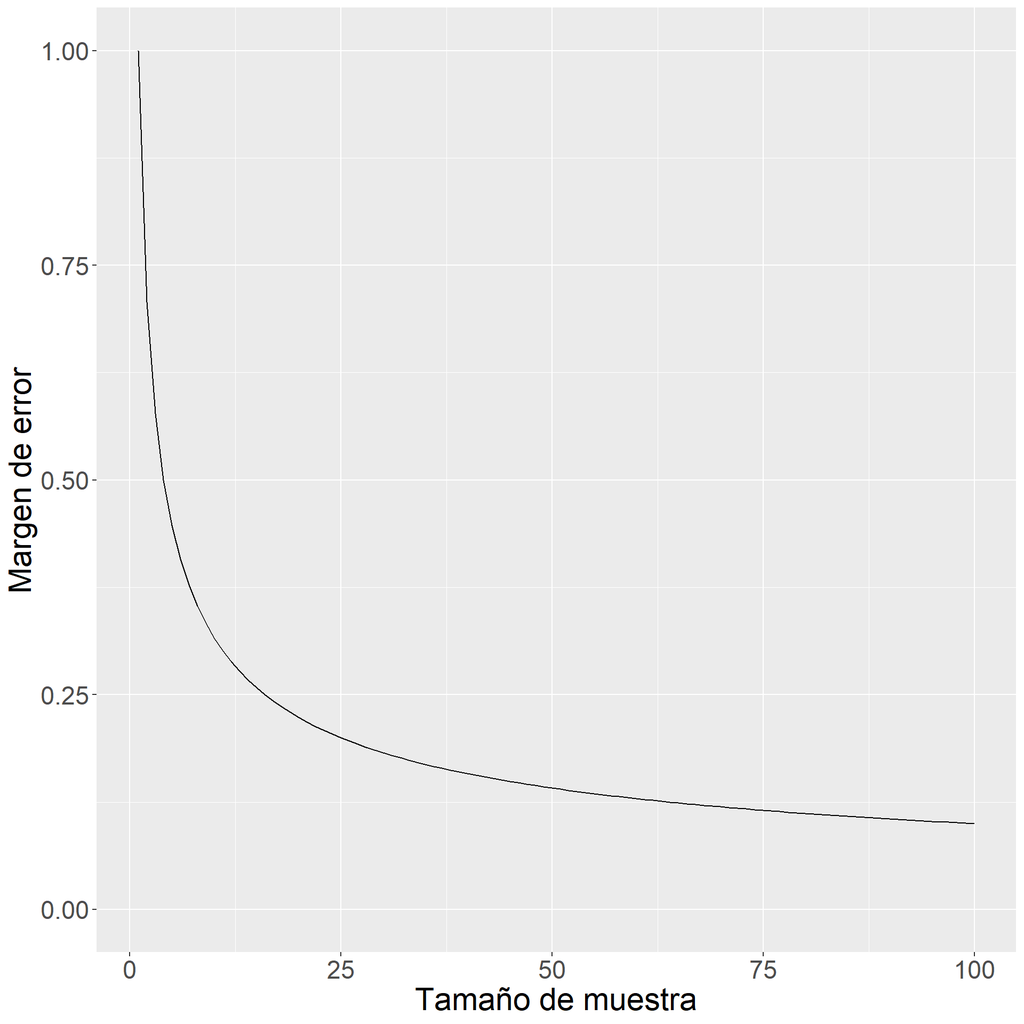